# Monitoreo Espacio-Temporal de la variación de los Glaciares Maladeta y Monte Perdido (Pirineos, España): Una Perspectiva Geomática

Mireya Fernández

Cargar las librerías necesarias

```r
setwd("E:/TFG/Series Temporales/Codigo/datos/limpio")

library(readr)
library(dplyr)
library(ggplot2)
library(lubridate)
library(readxl)
library(tidyverse)
library(tseries)
library(forecast)
library(tsoutliers)
library(expsmooth)
library(tsutils)
library (zoo)
library(imputeTS)
library(forecast)
```

# Superficie glaciar de Maladeta

```r
# Leer el archivo CSV con separador ;
datosMaladeta =read.csv("E:/TFG/Series Temporales/Codigo/datos/limpio/Maladeta-Area (2).csv",sep = ";")

# Verificar las primeras filas del dataframe original para entender el contenido
print(head(datosMaladeta))
```

|  | fecha | superficie |
| --- | --- | --- |
| 1 | 1984 | 19.81 |
| 2 | 1985 | NA |
| 3 | 1986 | NA |
| 4 | 1987 | NA |
| 5 | 1988 | NA |
| 6 | 1989 | NA |

```r
# Verificar la estructura del dataframe original
print(str(datosMaladeta))
```

```
'data.frame':   32 obs. of  2 variables:
 $ fecha     : int  1984 1985 1986 1987 1988 1989 1990 1991 1992 1993 ...
 $ superficie: num  19.8 NA NA NA NA ...
NULL
```

```r
# Verificar cuantos valores NA hay en las columnas seleccionadas
print(colSums(is.na(datosMaladeta[, c("fecha", "superficie")])))
```

```
     fecha superficie
         0         28
```

Creamos la serie temporal, con los datos originales

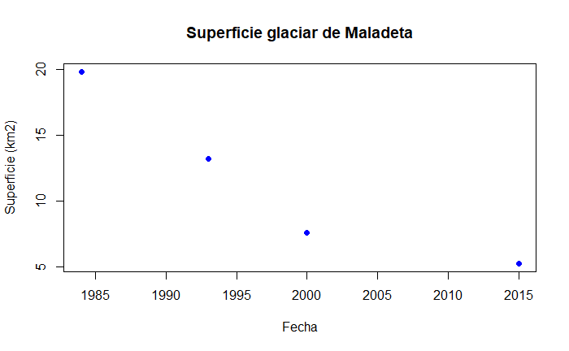

```r
sup_maladeta=ts(datosMaladeta$superficie, start=1984, frequency = 1)


plot(sup_maladeta, pch=19, type="o", col="blue", ylab="Superficie (km2)", xlab="Fecha", main="Superficie glaciar de Maladeta")
```

Debido a que existen datos faltantes, se procederá a realizar una interpolación para poder generar una predicción de la superficie glaciar en 10 años

### **Interpolación**

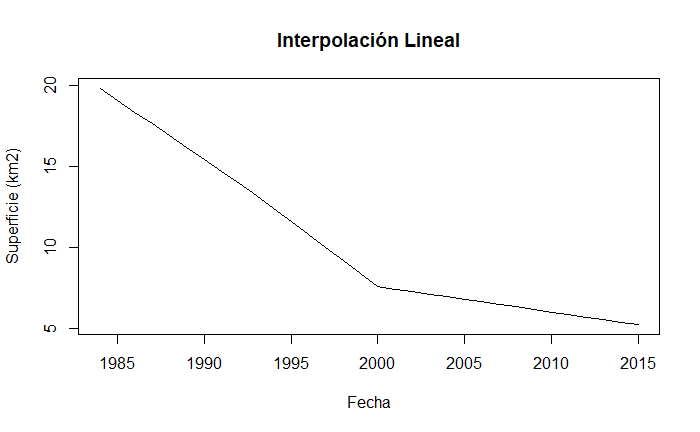

```r
# Método 1: Interpolación lineal
sup_ts_linear <- na.approx(sup_maladeta)
plot(sup_ts_linear, main="Interpolación Lineal", ylab="Superficie (km2)", xlab="Fecha")
```

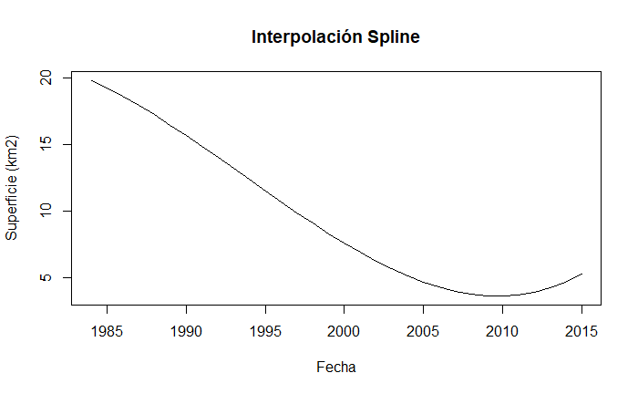

```r
# Método 2: Interpolación spline
sup_ts_spline <- na.spline(sup_maladeta)
plot(sup_ts_spline, main="Interpolación Spline", ylab="Superficie (km2)", xlab="Fecha")
```

A causa de los pocos datos que se disponían, una interpolacion lineal es la mejor opción ya que consigue generar muy bien la forma de la serie. Mientras que la interpolación mediante spline, realiza una curva ascendente la cual no es representativa ya que la serie no aumenta a partir del año 2015.

La interpolación lineal es una técnica utilizada para estimar valores intermedios dentro de un conjunto de datos conocidos. Cuando tenemos dos puntos con valores conocidos, esta técnica supone que el cambio entre esos puntos es constante, y, por lo tanto, se puede aproximar mediante una línea recta. De esta forma, podemos predecir el valor de una variable en un punto intermedio basado en la relación lineal entre los datos. Es una herramienta útil cuando los datos muestran un comportamiento relativamente lineal.

### **Análisis descriptivo**

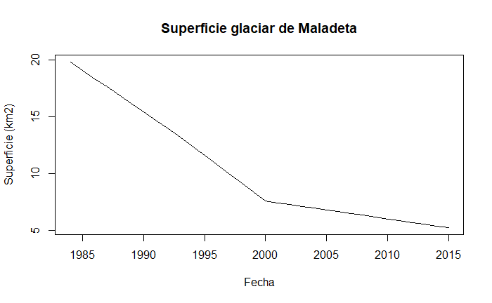

```r
maladeta_ts <- ts(sup_ts_linear, frequency=1, start=1984)
plot(sup_ts_linear, pch=19, type="l", main="Superficie glaciar de Maladeta",ylab="Superficie (km2)", xlab="Fecha")
```

A simple vista se ve que la serie tiene una tendencia decreciente

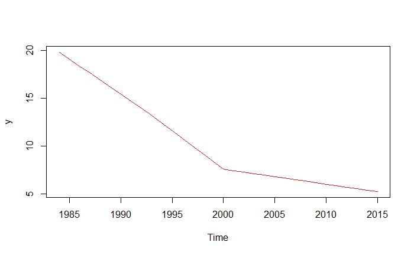

```r
cmav_sup=cmav(maladeta_ts,outplot=TRUE)
```

```r
coxstuart(cmav_sup)
```

```
$H
[1] 1

$p.value
[1] 1.525879e-05

$Htxt
[1] "H1: There is change (upwards or downwards)."
```